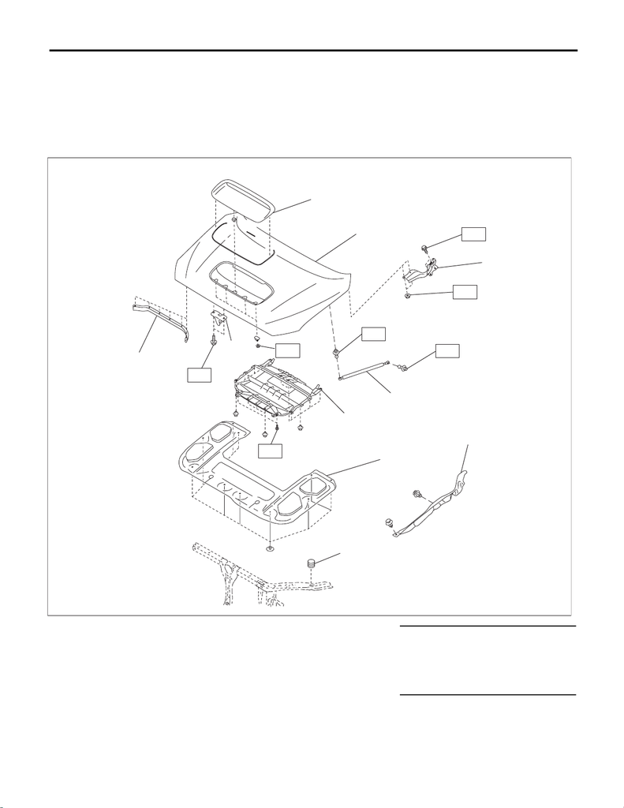

EB-2

General Description

EXTERIOR BODY PANELS

1. General Description

A: SPECIFICATION

Refer to Body Repair Manual for the dimensions of the body.

B: COMPONENT

1. FRONT HOOD

(2) Hood COMPL - front (7) Insulator - front hood T1: 4.5 (0.5, 3.3)

(3) Hinge COMPL - front hood (8) Duct - inner front hood T2: 20 (2.0, 14.8)

(4) Stay ASSY - front hood (9) Striker - front hood T3: 25 (2.5, 18.4)

EB-00988

T1

T2

T2

T3

T3

T4

T1

(1)

(2)

(3)

(5)

(6)

(7)

(9)

(10)

(8)

(4)

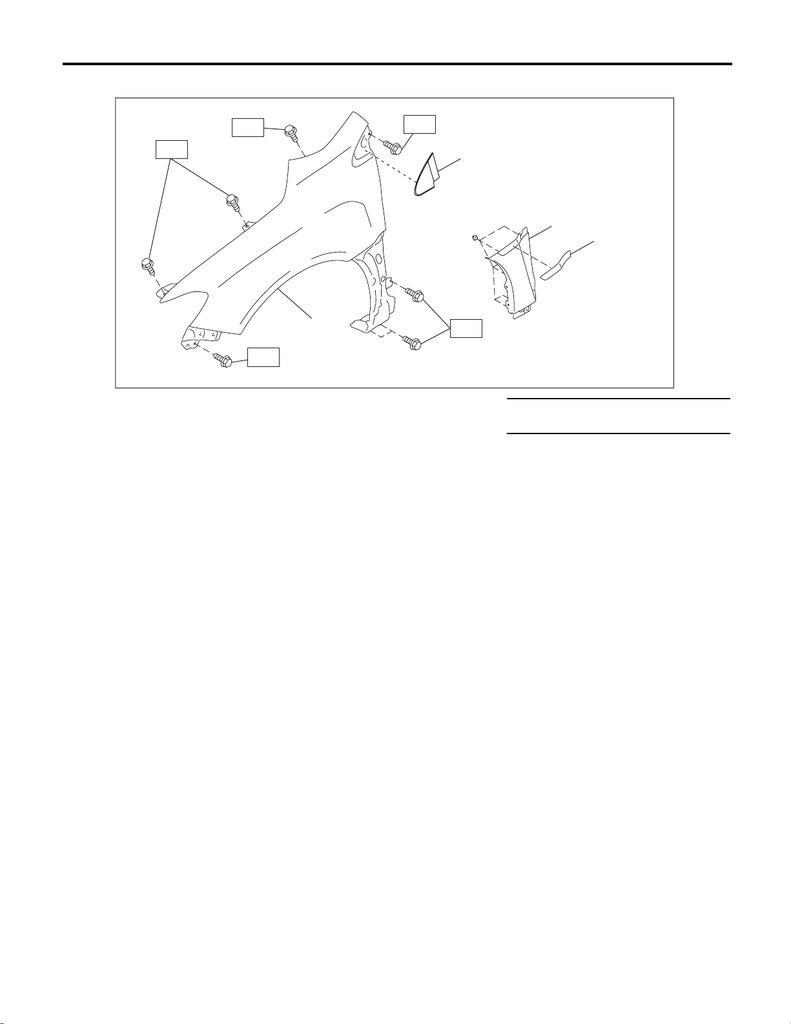

EB-3

General Description

EXTERIOR BODY PANELS

2. FRONT FENDER

(1) Cover ASSY - A pillar (3) Molding Tightening torque: N·m (kgf-m, ft-lb)

(2) Garnish ASSY - fender (4) Fender COMPL - front T: 7.5 (0.8, 5.5)

EB-00989

T

T

T

T

T

(1)

(4)

(3)

(2)

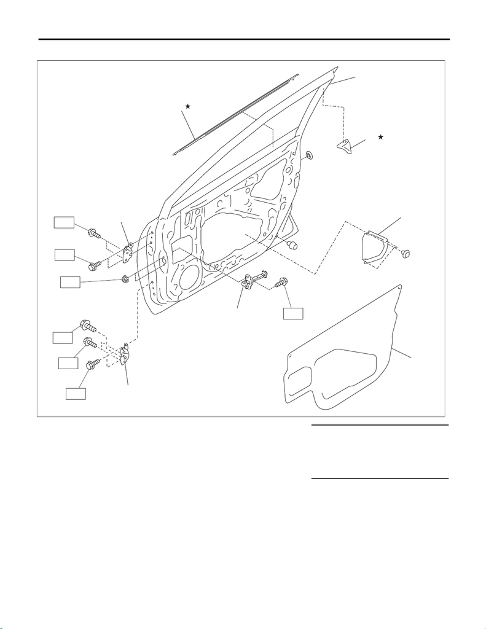

EB-4

General Description

EXTERIOR BODY PANELS

3. FRONT DOOR

(1) Panel ASSY - front door (5) Checker ASSY - front door Tightening torque: N·m (kgf-m, ft-lb)

(2) Cover B pillar - front door INN (6) Lower hinge - front door T1: 7.5 (0.8, 5.5)

(3) Front door inner pad (7) Upper hinge - front door T2: 25 (2.5, 18.4)

(4) Sealing cover - front door (8) Weather strip outer - front door T3: 30 (3.1, 22.1)

T4: 33 (3.4, 24.3)

EB-00953

T2

T4

T2

T1

T3

T3

T3

(1)

(2)

(3)

(4)

(5)

(6)

(7)

(8)

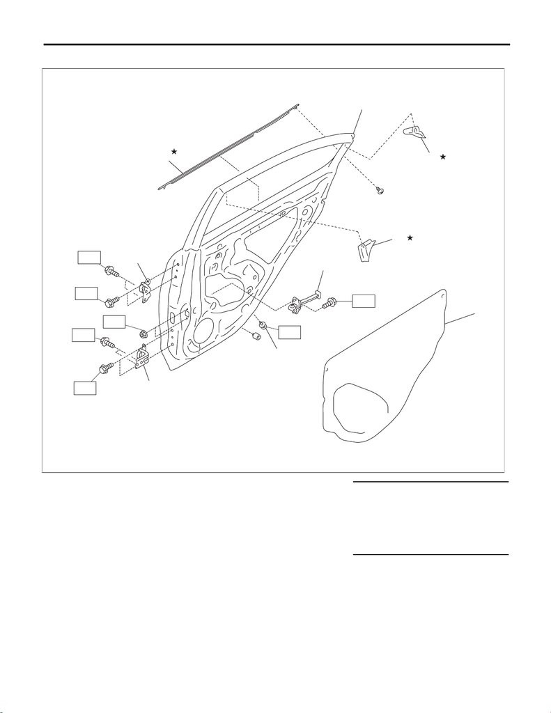

EB-5

General Description

EXTERIOR BODY PANELS

4. REAR DOOR

(1) Panel ASSY - rear door (6) Catcher - rear door Tightening torque: N·m (kgf-m, ft-lb)

(2) Cover C pillar - rear door INN (7) Lower hinge - rear door T1: 7.5 (0.8, 5.5)

(3) Cover B pillar - rear door INN (8) Upper hinge - rear door T2: 25 (2.5, 18.4)

(4) Sealing cover - rear door (9) Weather strip outer - rear door T3: 30 (3.1, 22.1)

(5) Checker ASSY - rear door T4: 33 (3.4, 24.3)

T5: 38 (3.9, 28.0)

EB-00954

(1)

T1

(4)

(5)

(7)

(8)

T2

T3

T2

T3

T4

(6)

T5

(9)

(3)

(2)

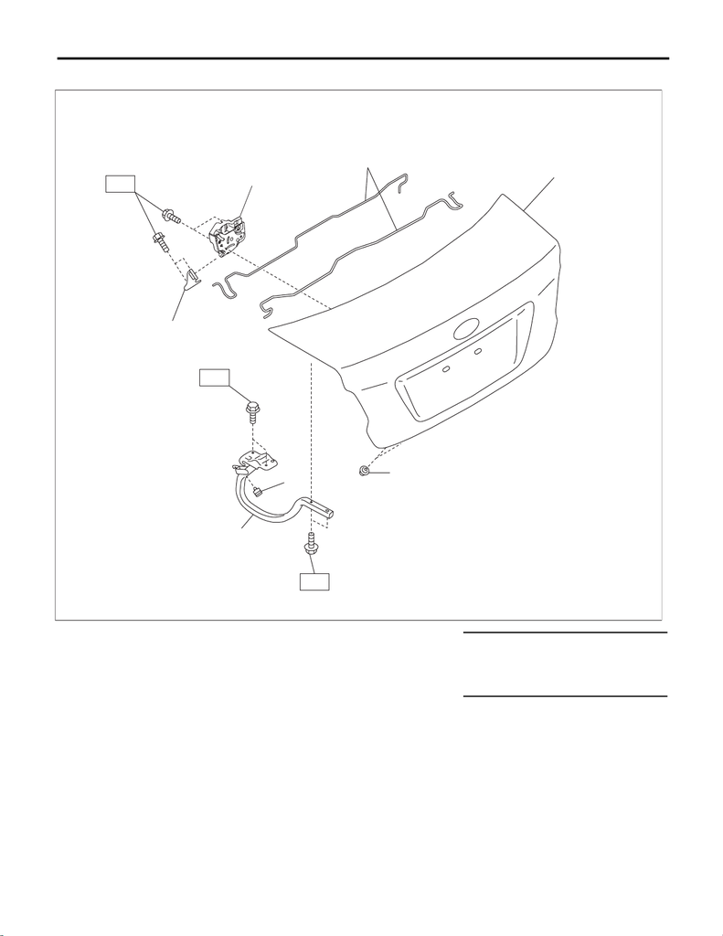

EB-6

General Description

EXTERIOR BODY PANELS

5. TRUNK LID PANEL

(1) Trunk lid COMPL (5) Striker - trunk Tightening torque: N·m (kgf-m, ft-lb)

(2) Stopper - trunk lid (6) Lock ASSY - trunk lid T1: 7.5 (0.8, 5.5)

(3) Stopper - trunk (7) Torsion bar - trunk lid T2: 14 (1.4, 10.3)

(4) Trunk lid arm ASSY T3: 18 (1.8, 13.3)

EB-00955

(1)

T2

(7)

(6)

(5)

(2)

(4)

(3)

T3

T1

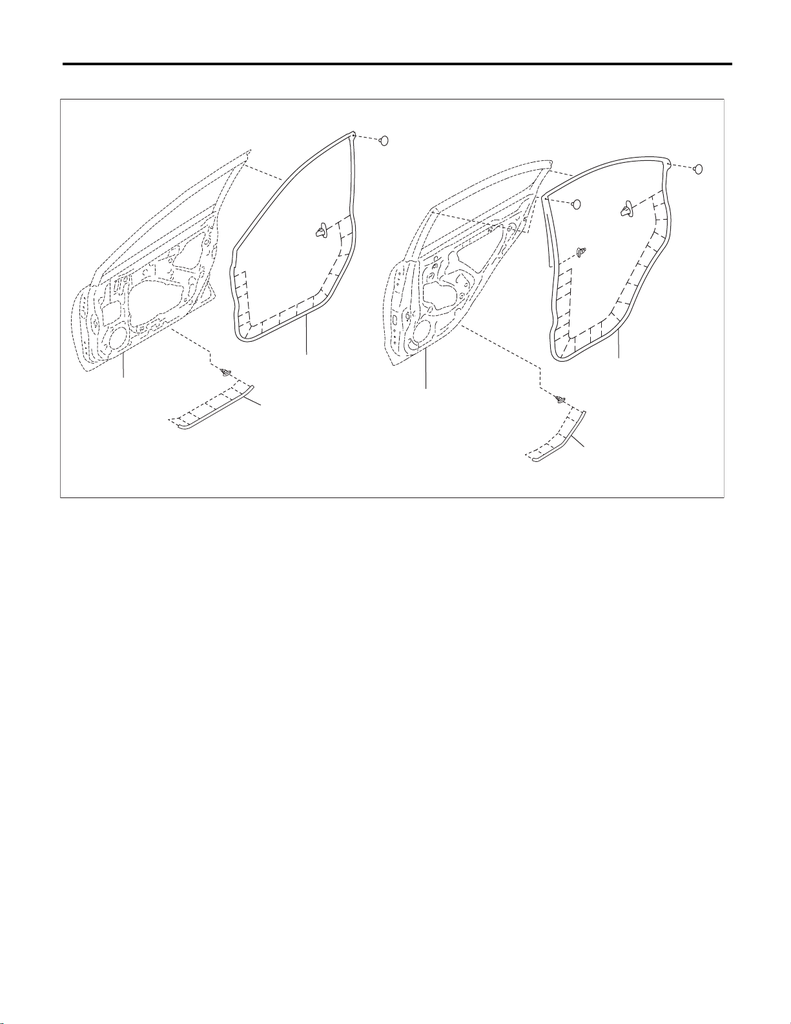

EB-7

General Description

EXTERIOR BODY PANELS

6. WEATHER STRIP

(1) Panel ASSY - front door (3) Weather strip - front door (5) Weather strip - rear door - lower

(2) Weather strip - front door - lower (4) Panel ASSY - rear door (6) Weather strip - rear door

EB-00956

(1)

(2)

(4)

(5)

(6)

(3)

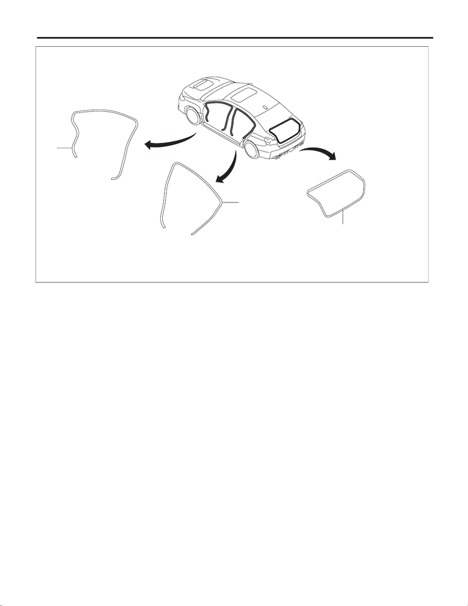

EB-8

General Description

EXTERIOR BODY PANELS

C: CAUTION

Exterior body panels are heavy. When removing and installing them, do not drop and damage the panels. Al-

so, be careful not to scratch the coated surfaces of the panels.

(1) Weather strip - body side flange

front

(2) Weather strip - body side flange

rear

(3) Weather strip - trunk lid

EB-00957

(1)

(2)

(3)

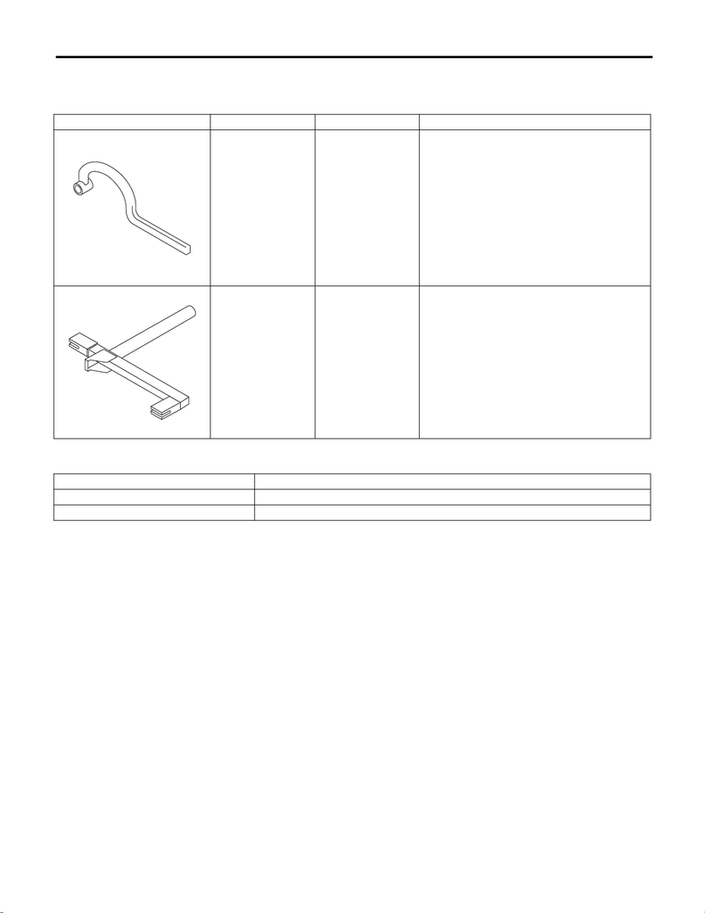

EB-9

General Description

EXTERIOR BODY PANELS

D: PREPARATION TOOL

1. SPECIAL TOOL

2. GENERAL TOOL

ILLUSTRATION TOOL NUMBER DESCRIPTION REMARKS

925610000 WRENCH Used for removing and installing door hinge.

99099FJ000 REMOVER Used for removing and installing the trunk tor-

sion bar.

TOOL NAME REMARKS

Support jack Used for supporting door panel.

Clip remover Used for removing various types of clips.

ST-925610000

ST99099FJ000